# Integrantes do grupo

Esses são os três membros do grupo. Utilizamos um *.csv* para deixar mais dinâmico a apresentação. Para isso, usamos a biblioteca **Pandas**.

```python
import pandas

hl_data = pandas.read_csv('../../docs/hl_atividade_1.csv')
hl_df = pandas.DataFrame(hl_data)
hl_df[:3]
```

|  | Member | Hentai Lab Corp | Relevance | Semester that joined | Founder |
| --- | --- | --- | --- | --- | --- |
| 0 | Matheus Marques Polillo | West | 1.00 | 2 | True |
| 1 | Thiago Aires | West | 1.00 | 2 | True |
| 2 | Marcello Bertero | West | 0.97 | 3 | False |

# Pré-processamento de dados

## Character

Enquanto no R, o tipo de variável que representa dados em formato de texto é **character**, enquanto no Python é **str** (String). Usando `type()`, passando a variável que contém o dado como parâmetro do método podemos ver seu tipo.

```python
type(hl_df.loc[0, 'Member'])
```

```
str
```

Como parâmetro do método foi passado o `dataframe.loc`, responsável por localizar certo valor em determinada linha e/ou coluna de um data frame. Neste caso, foi pego o nome do *Polillo* pra servir como valor para identificação de tipo. Para saber como fica o *output* do valor usado para identificar o tipo **str**, ele fica desta forma:

```python
hl_df.loc[0, 'Member']
```

```
'Matheus Marques Polillo'
```

## Numeric

Dentro do R há um tipo de variável que comporta valores numéricos com casas decimais, ou seja, valores após a vírgula, enquanto no Python este tipo (**numeric**) é representado por um valor flutuante: o **float**. Usando `type()`, passando a variável que contém o dado como parâmetro do método podemos ver seu tipo.

```python
type(hl_df.loc[2, 'Relevance'])
```

```
numpy.float64
```

Para ficar melhor a visualização do valor **float**, observe o seguinte exemplo feito a mão:

```python
peso = 76.2
type(peso)
```

```
float
```

Ambos tem valores flutuantes, observe:

```python
print('Valor no data frame:', hl_df.loc[2, 'Relevance'])
print('Valor da variável criada a mão:', peso)
```

```
Valor no data frame: 0.97
Valor da variável criada a mão: 76.2
```

## Integer

Diferente dos tópicos anteriores, o tipo inteiro nas duas linguagens (R e Python) é o mesmo: o **int**. Usando `type()`, passando a variável que contém o dado como parâmetro do método podemos ver seu tipo.

```python
type(hl_df.loc[0, 'Semester that joined'])
```

```
numpy.int64
```

Assim como no exemplo anterior, se olharmos uma variável feita a mão vamos notar que têm valores parecidos, portanto o tipo continua sendo o mesmo, mudando apenas a forma de sua anotação (os valores do data frame tem o tipo representado pelo **NumPy**)!

```python
qtdFilhos = 3
type(qtdFilhos)
```

```
int
```

```python
print('Valor no data frame:', hl_df.loc[0, 'Semester that joined'])
print('Valor da variável criada a mão:', qtdFilhos)
```

```
Valor no data frame: 2
Valor da variável criada a mão: 3
```

## Logical

O valor lógico do R (**logical**) é representado no Python por **bool**. Ambos tem valores lógicos, ou seja, apenas **True** e **False**. Usando `type()`, passando a variável que contém o dado como parâmetro do método podemos ver seu tipo.

```python
type(hl_df.loc[0, 'Founder'])
```

```
numpy.bool_
```

Seguindo os exemplos dados anteriormente, é possível mostrar que o valor do data frame e o valor feito a mão dentro da linguagem são parecidos, apenas mudando a forma como é imprimido seu tipo. Veja:

```python
temCarro = True
type(temCarro)
```

```
bool
```

```python
print('Valor no data frame:', hl_df.loc[0, 'Founder'])
print('Valor da variável criada a mão:', temCarro)
```

```
Valor no data frame: True
Valor da variável criada a mão: True
```

## Vectors

> *"O vetor pode ser considerado uma variável multidimensional indexada, ou seja, uma variável que tem a capacidade de guardar mais de um valor simultaneamente do mesmo tipo."*

> -- [Renata Florence dos Santos](http://nerdsti.com.br/?author=2)

```python
hl_relevance_vector = []
for i in range(0, 10):
    hl_relevance_vector.append(hl_df.loc[i, 'Relevance'])
hl_relevance_vector
```

```
[1.0, 1.0, 0.97, 1.0, 1.0, 0.99, 0.22, 0.22, 0.58, 0.35]
```

```python
hl_names_vector = []
for i in range(0, 10):
    hl_names_vector.append(hl_df.loc[i, 'Member'])
hl_names_vector
```

```
['Matheus Marques Polillo',
 'Thiago Aires',
 'Marcello Bertero',
 'Felipe Leitão',
 'João Pedro Libonati',
 'Bruno Seiti',
 'Alexandre de Godoy',
 'Bruno Paes',
 'Miguel Kannan',
 'Guilherme Reis']
```

## Lists

> *"Lists are just like the arrays, declared in other languages. Lists need not be homogeneous always which makes it a most powerful tool in Python. A single list may contain DataTypes like Integers, Strings, as well as Objects. Lists are also very useful for implementing stacks and queues. Lists are mutable, and hence, they can be altered even after their creation."*

> -- [GeeksforGeeks](https://www.geeksforgeeks.org/python-list/)

```python
hl_list = []
for i in range(0, 10):
    hl_list.append(hl_df.loc[i, 'Member'])
    hl_list.append(hl_df.loc[i, 'Relevance'])
    hl_list.append(hl_df.loc[i, 'Founder'])
print(hl_list)
```

[output not shown]

## Matrizes

As **matrizes** não são mais do que vetores, contudo elas tem múltiplas dimensões, diferentemente dos vetores que é unidimensional (uma dimensão). Para montarmos uma matriz simples bidimensional iremos utilizar a biblioteca **Numpy**.

```python
import numpy

hl_vector_1 = [hl_df.loc[0, 'Member'], hl_df.loc[1, 'Member']]
hl_vector_2 = [hl_df.loc[2, 'Member'], hl_df.loc[3, 'Member']]
hl_matrix = numpy.matrix([hl_vector_1, hl_vector_2])
print(hl_matrix)
```

```
[['Matheus Marques Polillo' 'Thiago Aires']
 ['Marcello Bertero' 'Felipe Leitão']]
```

## Data frame

> Estrutura de dados tabular bidimensional, mutável em tamanho e potencialmente heterogênea, com eixos rotulados (linhas e colunas). As operações aritméticas são alinhadas nos rótulos de linha e coluna. Pode ser pensado como um contêiner do tipo ditado para objetos **Series**. A estrutura de dados principal dos **Pandas**.

> -- [Pandas](https://pandas.pydata.org/pandas-docs/stable/reference/api/pandas.DataFrame.html)

É importante ressaltar que apenas listas de tamanhos iguais podem formar um data frame!

Para esta operação utilizamos a biblioteca **Pandas** no qual, através do método `pandas.DataFrame()` construímos um data frame a partir de um dicionário.

```python
hl_members = pandas.DataFrame({'Member': hl_df["Member"], 'Founder': hl_df['Founder']})
hl_members
```

|  | Member | Founder |
| --- | --- | --- |
| 0 | Matheus Marques Polillo | True |
| 1 | Thiago Aires | True |
| 2 | Marcello Bertero | False |
| 3 | Felipe Leitão | True |
| 4 | João Pedro Libonati | True |
| 5 | Bruno Seiti | False |
| 6 | Alexandre de Godoy | False |
| 7 | Bruno Paes | False |
| 8 | Miguel Kannan | False |
| 9 | Guilherme Reis | False |

```python
hl_corp = pandas.DataFrame({'Member': hl_df["Member"], 'Hentai Lab Corp': hl_df['Hentai Lab Corp']})
hl_corp
```

|  | Member | Hentai Lab Corp |
| --- | --- | --- |
| 0 | Matheus Marques Polillo | West |
| 1 | Thiago Aires | West |
| 2 | Marcello Bertero | West |
| 3 | Felipe Leitão | East |
| 4 | João Pedro Libonati | East |
| 5 | Bruno Seiti | East |
| 6 | Alexandre de Godoy | NaN |
| 7 | Bruno Paes | NaN |
| 8 | Miguel Kannan | NaN |
| 9 | Guilherme Reis | NaN |

## Factors

Os **factors** são variáveis qualitativas que podem ser incluídas nos modelos.

```python
hl_relevance = []
for i in range(0, 10):
    hl_relevance.append(hl_df.loc[i,'Relevance'])
hl_relevance_factor = pandas.Series(hl_relevance, dtype='category')
hl_relevance_factor
```

```
0    1.00
1    1.00
2    0.97
3    1.00
4    1.00
5    0.99
6    0.22
7    0.22
8    0.58
9    0.35
dtype: category
Categories (6, float64): [0.22, 0.35, 0.58, 0.97, 0.99, 1.00]
```

```python
hl_founder = []
for i in range(0, 10):
    hl_founder.append(hl_df.loc[i,'Founder'])
hl_founder_factor = pandas.Series(hl_founder, dtype='category')
hl_founder_factor
```

```
0     True
1     True
2    False
3     True
4     True
5    False
6    False
7    False
8    False
9    False
dtype: category
Categories (2, object): [False, True]
```

## Missing values

Enquanto no R os campos que não há valor informado são chamados de **NaN**, no Python são chamados de **None**. Montamos um vetor com alguns campos com valores "não-respostas", ou seja, **None** para mostrarmos como seria.

```python
none_vector = [12.3, 19.0, 65.14, None, None, 1.3, None]
none_vector
```

```
[12.3, 19.0, 65.14, None, None, 1.3, None]
```

Contudo, o Python não tem uma função nativa para saber se um valor é **None** ou não, portanto cabe a nós desenvolver esta função ou utilizar uma biblioteca que já tenha ela, que no caso é o **NumPy**.

```python
print(numpy.isnan(none_vector))
```

```
---------------------------------------------------------------------------
TypeError                                 Traceback (most recent call last)
<ipython-input-23-db8b7ee02edd> in <module>
----> 1 print(numpy.isnan(none_vector))

TypeError: ufunc 'isnan' not supported for the input types, and the inputs could not be safely coerced to any supported types according to the casting rule ''safe''
```

Mas, como mostra o erro acima, é necessário ter consciência de que o método `numpy.isnan()` do **NumPy** é limitado ao seu próprio valor nulo. Portanto, faremos das duas formas: construíremos um método para verificar o valor **None** e usaremos também o método `numpy.isnan()`.

Começando pelo método do **NumPy**, vamos ajustar o vetor que criamos.

```python
none_vector = [12.3, 19.0, 65.14, numpy.nan, numpy.nan, 1.3, numpy.nan]
none_vector
```

```
[12.3, 19.0, 65.14, nan, nan, 1.3, nan]
```

```python
print(numpy.isnan(none_vector))
```

```
[False False False  True  True False  True]
```

Aí está, o **NumPy** consegue identificar os valores nulos quando utilizamos o método da própria biblioteca para gerar seus próprios valores nulos.

Agora, vamos criar nosso próprio método de verificação.

```python
def is_none(v):
    none_vector = []
    for i in v:
        if i != None:
            none_vector.append(False)
        else:
            none_vector.append(True)
    return none_vector
```

Este é o método `is_none()`. Ele recebe como parâmetro um vetor. Dentro deste método há um vetor que receberá valores booleanos baseado na verificação do método. Ele verificará, em cada posição do vetor, onde há valor **None** e onde não há. No fim, ele retorna o vetor com os valores booleanos.

```python
none_vector = [12.3, 19.0, 65.14, None, None, 1.3, None]
```

```python
is_none(none_vector)
```

```
[False, False, False, True, True, False, True]
```

## Subsetting

**Subsetting** é a capacidade do Python de retornar um ou mais valores baseado no número correspondente a posição do vetor. Ou seja, valor(es) correspondente(s) a posição 0 (no R é 1) de um certo vetor serão retornadas caso o programa seja ordenado a tal. Um exemplo disso é o que foi feito na apresentação dos integrantes do grupo.

```python
hl_df[:3]
```

|  | Member | Hentai Lab Corp | Relevance | Semester that joined | Founder |
| --- | --- | --- | --- | --- | --- |
| 0 | Matheus Marques Polillo | West | 1.00 | 2 | True |
| 1 | Thiago Aires | West | 1.00 | 2 | True |
| 2 | Marcello Bertero | West | 0.97 | 3 | False |

Aqui é selecionado apenas os três primeiros valores do data frame. Vamos usar o vetor de *members* criado anteriormente no tópico de vetores para aplicar o **subsetting** nele.

```python
print(hl_names_vector[0])
print("\n=======================\n")
print(hl_names_vector[1:3])
print("\n=======================\n")
print(hl_names_vector[:10])
```

```
Matheus Marques Polillo

=======================

['Thiago Aires', 'Marcello Bertero']

=======================

['Matheus Marques Polillo', 'Thiago Aires', 'Marcello Bertero', 'Felipe Leitão', 'João Pedro Libonati', 'Bruno Seiti', 'Alexandre de Godoy', 'Bruno Paes', 'Miguel Kannan', 'Guilherme Reis']
```

Agora, vamos utilizar o data frame inteiro para podermos ver como o **subsetting** se comporta quando aplica a ele.

```python
print(hl_df['Member'].to_string(index=False))
```

```
 Matheus Marques Polillo
            Thiago Aires
        Marcello Bertero
           Felipe Leitão
     João Pedro Libonati
             Bruno Seiti
      Alexandre de Godoy
              Bruno Paes
           Miguel Kannan
          Guilherme Reis
```

## Logical subsetting

Funciona da mesma forma que o **subsetting** apresentado anteriormente, porém ele trabalha com valores booleanos que são resultados de verificações de existência feitas pelo Python. Para entender melhor, observe:

```python
is_polillo = hl_df.Member == "Matheus Marques Polillo"
hl_df.loc[is_polillo]
```

|  | Member | Hentai Lab Corp | Relevance | Semester that joined | Founder |
| --- | --- | --- | --- | --- | --- |
| 0 | Matheus Marques Polillo | West | 1.0 | 2 | True |

Como pode ser observado acima, a variável `is_polillo` carrega um vetor de valores booleanos, resultantes da verificação feita pelo restante da linha de código, analisando se há ou não o valor *Matheus Marques Polillo* dentro da coluna *Members* do data frame. No meio do vetor desta variável deverá haver um **True** responsável por avisar em que índice o valor *Matheus Marques Polillo* se encontra para que assim o `dataframe.loc[]` funcione. Veja o valor da variável:

```python
is_polillo
```

```
0     True
1    False
2    False
3    False
4    False
5    False
6    False
7    False
8    False
9    False
Name: Member, dtype: bool
```

Vamos fazer de outra forma. Desta vez, coletaremos apenas os membros fundadores do grupo, ou seja, que tem o valor booleano **True** na coluna *Founder*.

```python
is_founder = hl_df.Founder == True
hl_df.loc[is_founder]
```

|  | Member | Hentai Lab Corp | Relevance | Semester that joined | Founder |
| --- | --- | --- | --- | --- | --- |
| 0 | Matheus Marques Polillo | West | 1.0 | 2 | True |
| 1 | Thiago Aires | West | 1.0 | 2 | True |
| 3 | Felipe Leitão | East | 1.0 | 2 | True |
| 4 | João Pedro Libonati | East | 1.0 | 2 | True |

```python
is_founder
```

```
0     True
1     True
2    False
3     True
4     True
5    False
6    False
7    False
8    False
9    False
Name: Founder, dtype: bool
```

## Conversão de tipos

Utilizando o mesmo dataset anterior, vamos coletar um dos valores do *semestre que juntou-se* e trocar de **int** para **float**.

```python
hl_stj = hl_df.loc[0, 'Semester that joined']
type(hl_stj)
```

```
numpy.int64
```

```python
hl_stj = float(hl_stj)
type(hl_stj)
```

```
float
```

É possível fazer isso com vários tipos de valores. Vamos tentar com outros 2! Começaremos pelo *Relevance* e terminaremos com o *Founder*.

```python
hl_r = hl_df.loc[0, 'Relevance']
type(hl_r)
```

```
numpy.float64
```

```python
hl_r = int(hl_r)
type(hl_r)
```

```
int
```

```python
hl_f = hl_df.loc[0, 'Founder']
type(hl_f)
```

```
numpy.bool_
```

```python
hl_f = str(hl_f)
type(hl_f)
```

```
str
```

## Merge( )

Este método pertence a biblioteca **Pandas**, responsável por mesclar dois data frames. Função bastante parecida com as funções de *join* que usamos em SQL.

Para fazermos um `merge()` que funcione com excelência vamos usar dois data frames que tenham uma coluna e seus valores parecidos para que o método identifique quais são os valores iguais e, através disso, faça o *merge* com os valores pertencentes as linhas corretas. Para isso, vamos usar um data frame que irá coletar o nome dos membros e se ele é ou não fundador, e outro data frame que irá coletar o nome dos membros (pra fazer a associação com o outro data frame) e de qual corporação do HL ele pertence. Observe:

```python
hl_corp_df = pandas.DataFrame({'Member': hl_df["Member"], 'Hentai Lab Corp': hl_df['Hentai Lab Corp']})
hl_member_df = pandas.DataFrame({'Member': hl_df["Member"], 'Founder': hl_df['Founder']})
hl_merge_df = pandas.merge(hl_corp_df, hl_member_df)

hl_merge_df
```

|  | Member | Hentai Lab Corp | Founder |
| --- | --- | --- | --- |
| 0 | Matheus Marques Polillo | West | True |
| 1 | Thiago Aires | West | True |
| 2 | Marcello Bertero | West | False |
| 3 | Felipe Leitão | East | True |
| 4 | João Pedro Libonati | East | True |
| 5 | Bruno Seiti | East | False |
| 6 | Alexandre de Godoy | NaN | False |
| 7 | Bruno Paes | NaN | False |
| 8 | Miguel Kannan | NaN | False |
| 9 | Guilherme Reis | NaN | False |

Vamos aplicar agora este conceito em um dataset retirado da internet e que iremos utilizar junto deste outro dataset montado a mão (o HL) no início do *notebook*. O dataset se chama [**Video Game Sales**](https://www.kaggle.com/gregorut/videogamesales).

> *"This dataset contains a list of video games with sales greater than 100,000 copies."*

> por GregorySmith, usuário do Kaggle

Este *dataset* é 16.598x11 (16.598 amostras com 11 colunas).

```python
vgs_data = pandas.read_csv("../../docs/vgsales.csv")
vgs_df = pandas.DataFrame(vgs_data)

vgs_df.head()
```

|  | Rank | Name | Platform | Year | Genre | Publisher | NA_Sales | EU_Sales | JP_Sales | Other_Sales | Global_Sales |
| --- | --- | --- | --- | --- | --- | --- | --- | --- | --- | --- | --- |
| 0 | 1 | Wii Sports | Wii | 2006.0 | Sports | Nintendo | 41.49 | 29.02 | 3.77 | 8.46 | 82.74 |
| 1 | 2 | Super Mario Bros. | NES | 1985.0 | Platform | Nintendo | 29.08 | 3.58 | 6.81 | 0.77 | 40.24 |
| 2 | 3 | Mario Kart Wii | Wii | 2008.0 | Racing | Nintendo | 15.85 | 12.88 | 3.79 | 3.31 | 35.82 |
| 3 | 4 | Wii Sports Resort | Wii | 2009.0 | Sports | Nintendo | 15.75 | 11.01 | 3.28 | 2.96 | 33.00 |
| 4 | 5 | Pokemon Red/Pokemon Blue | GB | 1996.0 | Role-Playing | Nintendo | 11.27 | 8.89 | 10.22 | 1.00 | 31.37 |

No caso deste dataset nós iremos aplicar a função `merge()` em um data frame com os jogos e sua distribuidora e em um outro data frame com as vendas apenas da Europa, também carregando a coluna de jogos para que tenham valores padrões que o método consiga enxergar para assim termos um data frame que mostre os jogos, suas distribuidoras e o número de vendas na Europa.

```python
vgs_games_df = pandas.DataFrame({'Name': vgs_df['Name'], 'Publisher': vgs_df['Publisher']})
vgs_eu_sales_df = pandas.DataFrame({'Name': vgs_df['Name'], 'EU_Sales': vgs_df['EU_Sales']})
vgs_merge_df = pandas.merge(vgs_games_df, vgs_eu_sales_df)

vgs_merge_df[:10]
```

|  | Name | Publisher | EU_Sales |
| --- | --- | --- | --- |
| 0 | Wii Sports | Nintendo | 29.02 |
| 1 | Super Mario Bros. | Nintendo | 3.58 |
| 2 | Super Mario Bros. | Nintendo | 1.30 |
| 3 | Super Mario Bros. | Nintendo | 3.58 |
| 4 | Super Mario Bros. | Nintendo | 1.30 |
| 5 | Mario Kart Wii | Nintendo | 12.88 |
| 6 | Wii Sports Resort | Nintendo | 11.01 |
| 7 | Pokemon Red/Pokemon Blue | Nintendo | 8.89 |
| 8 | Tetris | Nintendo | 2.26 |
| 9 | Tetris | Nintendo | 0.69 |

## Concat( )

Diferentemente do `merge()` que une dois data frames em um data frame só (formatado), o `concat()` se preocupa em montar um data frame utilizando outros mas que se completam, ou seja, continuam na mesma coluna.

```python
vgs_games_part1_df = pandas.DataFrame({'Name': vgs_df.loc[:4, 'Name']})
vgs_games_part2_df = pandas.DataFrame({'Name': vgs_df.loc[5:9, 'Name']})
vgs_concat_df = pandas.concat([vgs_games_part1_df, vgs_games_part2_df], ignore_index=True)

vgs_concat_df
```

|  | Name |
| --- | --- |
| 0 | Wii Sports |
| 1 | Super Mario Bros. |
| 2 | Mario Kart Wii |
| 3 | Wii Sports Resort |
| 4 | Pokemon Red/Pokemon Blue |
| 5 | Tetris |
| 6 | New Super Mario Bros. |
| 7 | Wii Play |
| 8 | New Super Mario Bros. Wii |
| 9 | Duck Hunt |

## Replace( )

O método `replace()` é muito útil pois é encarregado de sobrescrever dados apenas indicando a coluna em que tal dado deverá ser sobescrito e qual o dado anterior. Ele é bastante simples e pode ser de grande ajuda quando se trabalha com data frames muito grandes como é o caso do nosso **Video Games Sales**.

```python
vgs_clone_df = vgs_df
vgs_clone_games_df = pandas.DataFrame({'Name': vgs_clone_df['Name'], 'Publisher': vgs_clone_df['Publisher']})

vgs_clone_game_replaced_df = vgs_clone_games_df['Name'].replace('Pokemon Red/Pokemon Blue', 'Smokémon')

vgs_clone_games_df = pandas.DataFrame({'Name': vgs_clone_game_replaced_df, 'Publisher': vgs_clone_df['Publisher']})
vgs_clone_games_df.head()
```

|  | Name | Publisher |
| --- | --- | --- |
| 0 | Wii Sports | Nintendo |
| 1 | Super Mario Bros. | Nintendo |
| 2 | Mario Kart Wii | Nintendo |
| 3 | Wii Sports Resort | Nintendo |
| 4 | Smokémon | Nintendo |

Para facilitar a visualização:

```python
is_smokemon = vgs_clone_games_df.Name == 'Smokémon'
vgs_clone_games_df[is_smokemon]
```

|  | Name | Publisher |
| --- | --- | --- |
| 4 | Smokémon | Nintendo |

```python
vgs_clone_games_df.loc[4, 'Name']
```

```
'Smokémon'
```

## Subset( )

Não encontramos nenhuma função em alguma biblioteca que possa executar este tipo de comando como é feito no R, portanto utilizamos o método `query()` cujo o nome já indica o que ele faz. Por se tratar de um método cujo a função é montar uma **query** utilizando o data frame como banco, então podemos fazer este tipo de consulta usando ele.

```python
vgs_df.query('Global_Sales > 30')
```

|  | Rank | Name | Platform | Year | Genre | Publisher | NA_Sales | EU_Sales | JP_Sales | Other_Sales | Global_Sales |
| --- | --- | --- | --- | --- | --- | --- | --- | --- | --- | --- | --- |
| 0 | 1 | Wii Sports | Wii | 2006.0 | Sports | Nintendo | 41.49 | 29.02 | 3.77 | 8.46 | 82.74 |
| 1 | 2 | Super Mario Bros. | NES | 1985.0 | Platform | Nintendo | 29.08 | 3.58 | 6.81 | 0.77 | 40.24 |
| 2 | 3 | Mario Kart Wii | Wii | 2008.0 | Racing | Nintendo | 15.85 | 12.88 | 3.79 | 3.31 | 35.82 |
| 3 | 4 | Wii Sports Resort | Wii | 2009.0 | Sports | Nintendo | 15.75 | 11.01 | 3.28 | 2.96 | 33.00 |
| 4 | 5 | Pokemon Red/Pokemon Blue | GB | 1996.0 | Role-Playing | Nintendo | 11.27 | 8.89 | 10.22 | 1.00 | 31.37 |
| 5 | 6 | Tetris | GB | 1989.0 | Puzzle | Nintendo | 23.20 | 2.26 | 4.22 | 0.58 | 30.26 |
| 6 | 7 | New Super Mario Bros. | DS | 2006.0 | Platform | Nintendo | 11.38 | 9.23 | 6.50 | 2.90 | 30.01 |

## GroupBy( )

O método `groupby()` é encarregado de, através de algum critério de separação (ou de seleção), os dados de um determinado data frame serão reorganizados em grupos, retornando um valor no formato de um data frame.

```python
vgs_publisher_sales_df = pandas.DataFrame({'Publisher': vgs_df['Publisher'], 'Global_Sales': vgs_df['Global_Sales']})
vgs_publisher_sales_df.groupby(['Publisher']).mean().head()
```

| Publisher | Global_Sales |
| --- | --- |
| 10TACLE Studios | 0.036667 |
| 1C Company | 0.033333 |
| 20th Century Fox Video Games | 0.388000 |
| 2D Boy | 0.040000 |
| 3DO | 0.281111 |

# Análise Descritiva

## Análise sem gráfico

O dataset que iremos utilizar já foi importado e explicado anteriormente, é o **Video Game Sales**.

```python
vgs_df.head()
```

|  | Rank | Name | Platform | Year | Genre | Publisher | NA_Sales | EU_Sales | JP_Sales | Other_Sales | Global_Sales |
| --- | --- | --- | --- | --- | --- | --- | --- | --- | --- | --- | --- |
| 0 | 1 | Wii Sports | Wii | 2006.0 | Sports | Nintendo | 41.49 | 29.02 | 3.77 | 8.46 | 82.74 |
| 1 | 2 | Super Mario Bros. | NES | 1985.0 | Platform | Nintendo | 29.08 | 3.58 | 6.81 | 0.77 | 40.24 |
| 2 | 3 | Mario Kart Wii | Wii | 2008.0 | Racing | Nintendo | 15.85 | 12.88 | 3.79 | 3.31 | 35.82 |
| 3 | 4 | Wii Sports Resort | Wii | 2009.0 | Sports | Nintendo | 15.75 | 11.01 | 3.28 | 2.96 | 33.00 |
| 4 | 5 | Pokemon Red/Pokemon Blue | GB | 1996.0 | Role-Playing | Nintendo | 11.27 | 8.89 | 10.22 | 1.00 | 31.37 |

Os passos já foram feitos duas vezes, um para importação do dataset feito a mão e outro para a importação do dataset **Video Game Sales**, contudo será explicado melhor as etapas aqui. Primeiramente importamos o arquivo .csv a partir da rota de onde o arquivo está, após isso inserimos ele como parâmetro para o método `pandas.DataFrame()` responsável pela criação de um data frame. Observe o processo novamente:

```python
vgs_data = pandas.read_csv("../../docs/vgsales.csv")
vgs_df = pandas.DataFrame(vgs_data)
```

Com isso já geramos o data frame que pode ser visto um pouco mais acima! Antes de fazer qualquer análise ou possíveis alterações, é necessário sabermos com que tipo de dados estamos lidando. Portanto, utilizamos o método `dataframe.dtypes` para sabermos qual o tipo de dado de cada coluna.

```python
vgs_df.dtypes
```

```
Rank              int64
Name             object
Platform         object
Year            float64
Genre            object
Publisher        object
NA_Sales        float64
EU_Sales        float64
JP_Sales        float64
Other_Sales     float64
Global_Sales    float64
dtype: object
```

Uma coisa que pode-se notar ao olhar o data frame e os *data types* é os nomes. Eles estão bem formatados, mas e se por acaso nós quisessemos alterá-los caso houvesse algum nome não formatado? Vamos alterar o nome de todas as colunas duas vezes: para não formato e, depois, para formatado novamente. Tudo isso utilizando o método `dataframe.columns`.

```python
vgs_columns_unformatted = ['rank', 'name', 'platform', 'year', 'genre', 'publisher', 'na sales', 'eu sales', 'jp sales',
                           'other sales', 'global sales']
vgs_df.columns = vgs_columns_unformatted
vgs_df.head()
```

|  | rank | name | platform | year | genre | publisher | na sales | eu sales | jp sales | other sales | global sales |
| --- | --- | --- | --- | --- | --- | --- | --- | --- | --- | --- | --- |
| 0 | 1 | Wii Sports | Wii | 2006.0 | Sports | Nintendo | 41.49 | 29.02 | 3.77 | 8.46 | 82.74 |
| 1 | 2 | Super Mario Bros. | NES | 1985.0 | Platform | Nintendo | 29.08 | 3.58 | 6.81 | 0.77 | 40.24 |
| 2 | 3 | Mario Kart Wii | Wii | 2008.0 | Racing | Nintendo | 15.85 | 12.88 | 3.79 | 3.31 | 35.82 |
| 3 | 4 | Wii Sports Resort | Wii | 2009.0 | Sports | Nintendo | 15.75 | 11.01 | 3.28 | 2.96 | 33.00 |
| 4 | 5 | Pokemon Red/Pokemon Blue | GB | 1996.0 | Role-Playing | Nintendo | 11.27 | 8.89 | 10.22 | 1.00 | 31.37 |

```python
vgs_df.columns
```

```
Index(['rank', 'name', 'platform', 'year', 'genre', 'publisher', 'na sales',
       'eu sales', 'jp sales', 'other sales', 'global sales'],
      dtype='object')
```

Agora, vamos deixá-lo mais bonito, apresentável, formatado utilizando o mesmo método.

```python
vgs_columns_formatted = ['Rank', 'Name', 'Platform', 'Year', 'Genre', 'Publisher', 'NA_Sales', 'EU_Sales', 'JP_Sales',
                           'Other_Sales', 'Global_Sales']
vgs_df.columns = vgs_columns_formatted
vgs_df.head()
```

|  | Rank | Name | Platform | Year | Genre | Publisher | NA_Sales | EU_Sales | JP_Sales | Other_Sales | Global_Sales |
| --- | --- | --- | --- | --- | --- | --- | --- | --- | --- | --- | --- |
| 0 | 1 | Wii Sports | Wii | 2006.0 | Sports | Nintendo | 41.49 | 29.02 | 3.77 | 8.46 | 82.74 |
| 1 | 2 | Super Mario Bros. | NES | 1985.0 | Platform | Nintendo | 29.08 | 3.58 | 6.81 | 0.77 | 40.24 |
| 2 | 3 | Mario Kart Wii | Wii | 2008.0 | Racing | Nintendo | 15.85 | 12.88 | 3.79 | 3.31 | 35.82 |
| 3 | 4 | Wii Sports Resort | Wii | 2009.0 | Sports | Nintendo | 15.75 | 11.01 | 3.28 | 2.96 | 33.00 |
| 4 | 5 | Pokemon Red/Pokemon Blue | GB | 1996.0 | Role-Playing | Nintendo | 11.27 | 8.89 | 10.22 | 1.00 | 31.37 |

```python
vgs_df.columns
```

```
Index(['Rank', 'Name', 'Platform', 'Year', 'Genre', 'Publisher', 'NA_Sales',
       'EU_Sales', 'JP_Sales', 'Other_Sales', 'Global_Sales'],
      dtype='object')
```

É possível até contar a quantidade de valores que cada dado da coluna apresenta. Por exemplo, quantas vezes a EA, Activision ou qualquer outra distribuidora aparece neste data frame? Com isso podemos deduzir até qual distribuidora teve mais jogos vendidos neste data frame.

```python
vgs_df['Publisher'].value_counts().head()
```

```
Electronic Arts                 1351
Activision                       975
Namco Bandai Games               932
Ubisoft                          921
Konami Digital Entertainment     832
Name: Publisher, dtype: int64
```

Baseado nisso é possível deduzir que a EA teve a maior quantidade de jogos vendidos dentre todas as distribuidoras presentes neste *dataset*.

Para podermos ir mais fundo, vamos fazer o cálculo do desvio-padrão mas baseado nas vendais globais (*Global_Sales*) para saber o quanto varia. Para ser feito, usaremos o método `numpy.std()` da biblioteca **NumPy** que receberá como parâmetro o data frame e a coluna que quer saber o desvio-padrão.

```python
vgs_standard_deviation = numpy.std(vgs_df['Global_Sales'])
vgs_standard_deviation
```

```
1.5549810910296504
```

Contudo, caso queira o desvio-padrão de todas as colunas de vendas, também é possível.

```python
vgs_sd_na = numpy.std(vgs_df['NA_Sales'])
vgs_sd_eu = numpy.std(vgs_df['EU_Sales'])
vgs_sd_jp = numpy.std(vgs_df['JP_Sales'])
vgs_sd_ot = numpy.std(vgs_df['Other_Sales'])

print('NA Sales Standard Deviation: ', vgs_sd_na)
print('EU Sales Standard Deviation: ', vgs_sd_eu)
print('JP Sales Standard Deviation: ', vgs_sd_jp)
print('Other Sales Standard Deviation: ', vgs_sd_ot)
print('Global Sales Standard Deviation: ', vgs_standard_deviation)
```

```
NA Sales Standard Deviation:  0.8166584270779742
EU Sales Standard Deviation:  0.5053360078008797
JP Sales Standard Deviation:  0.3092813308358745
Other Sales Standard Deviation:  0.1885827217691664
Global Sales Standard Deviation:  1.5549810910296504
```

```python
arr = [vgs_sd_na, vgs_sd_eu, vgs_sd_jp, vgs_sd_ot, vgs_standard_deviation]

print("arr : ", arr)
print("median of arr : ", numpy.median(arr))
```

```
arr :  [0.8166584270779742, 0.5053360078008797, 0.3092813308358745, 0.1885827217691664, 1.5549810910296504]
median of arr :  0.5053360078008797
```

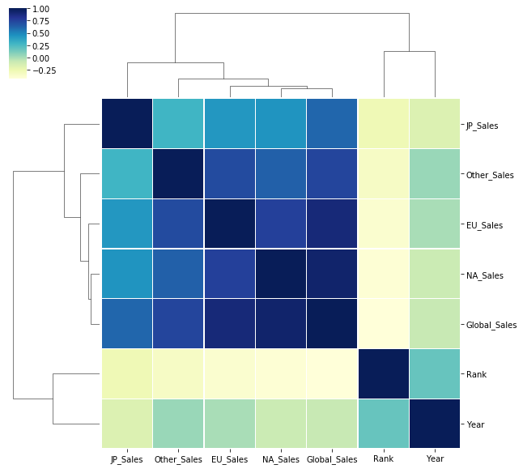

```python
import seaborn as sns
corrmat = vgs_data.corr()
cg = sns.clustermap(corrmat, cmap ="YlGnBu", linewidths = 0.1);

cg
```

```python
corrmat = vgs_data.corr()
corrmat
```

|  | Rank | Year | NA_Sales | EU_Sales | JP_Sales | Other_Sales | Global_Sales |
| --- | --- | --- | --- | --- | --- | --- | --- |
| Rank | 1.000000 | 0.178814 | -0.401362 | -0.379123 | -0.267785 | -0.332986 | -0.427407 |
| Year | 0.178814 | 1.000000 | -0.091402 | 0.006014 | -0.169316 | 0.041058 | -0.074735 |
| NA_Sales | -0.401362 | -0.091402 | 1.000000 | 0.767727 | 0.449787 | 0.634737 | 0.941047 |
| EU_Sales | -0.379123 | 0.006014 | 0.767727 | 1.000000 | 0.435584 | 0.726385 | 0.902836 |
| JP_Sales | -0.267785 | -0.169316 | 0.449787 | 0.435584 | 1.000000 | 0.290186 | 0.611816 |
| Other_Sales | -0.332986 | 0.041058 | 0.634737 | 0.726385 | 0.290186 | 1.000000 | 0.748331 |
| Global_Sales | -0.427407 | -0.074735 | 0.941047 | 0.902836 | 0.611816 | 0.748331 | 1.000000 |

Analisando as correlações dos anos em relação as vendas, concluímos que há correlação positiva se o ano e as vendas aumentam e diminuem quase sempre juntos. Se as vendas caem quase sempre que os anos passam,ou vice-versa, há correlação negativa. Se os aumentos e quedas nas vendas não tem efeito sobre o anos, não há correlação.

```python
meanmat = vgs_data.mean()
meanmat
```

```
Rank            8300.605254
Year            2006.406443
NA_Sales           0.264667
EU_Sales           0.146652
JP_Sales           0.077782
Other_Sales        0.048063
Global_Sales       0.537441
dtype: float64
```

## Análise com gráfico

Para melhorar a forma como analisamos o data frame vamos construir alguns gráficos que resumem bastante o que queremos encontrar. Começaremos pelo clássico histograma, utilizando o método `dataframe.plot()` para construir um. Ele é customizável, portanto ajuda bastante na hora da análise.

Para fazermos nosso **histograma** iremos utilizar a coluna de ano (*Year*) do data frame para sabermos qual foi o ano que mais teve vendas.

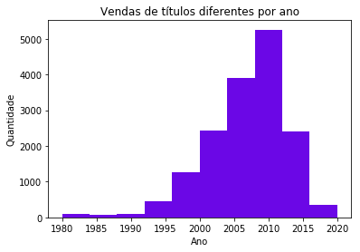

```python
vgs_histogram = vgs_df['Year'].plot(kind='hist', color='#6B07E6')
vgs_histogram.set_title('Vendas de títulos diferentes por ano')
vgs_histogram.set_xlabel('Ano')
vgs_histogram.set_ylabel('Quantidade')
```

Falando agora do código. Através do método `dataframe.plot()` criamos um histograma. É bom destacar que usamos a coluna *Year* dentro do dataframe para sinalizar ao método qual a coluna que queríamos plotar. Após isso, como parâmetros, passamos **hist** no **kind** para dizer que queríamos plotar um histograma e, por fim, o hexadecimal da cor roxa passada pelo **color**. Nas linhas de baixo apenas determinamos o título do histograma, o título do eixo X e o título do eixo Y!

Agora faremos um boxplot utilizando a mesma coluna (*Year*) para ver quais os anos tiveram menos títulos diferentes vendidos. Usando o mesmo método de plotar gráfico, porém mudamos apenas o hexadecimal da cor e a tag do **kind**, trocamos de **hist** para **box**, sinalizando para o método que queremos plotar um *boxplot*, não mais um *histograma*.

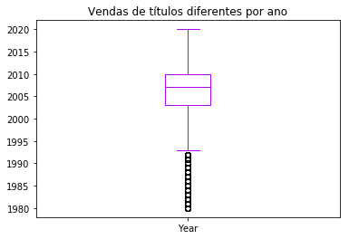

```python
vgs_boxplot = vgs_df['Year'].plot(kind='box', color='#B105F0')
vgs_boxplot.set_title('Vendas de títulos diferentes por ano')
```

É nítido a quantidade extravagante de **outliers** neste *boxplot*, o que mostra que os períodos que sucederam mais ou menos os anos 94 em diante tiveram uma grande quantidade de títulos diferentes vendidos, enquanto os anos que antecederam esses períodos venderam muito menos, não é atoa que se apresentam como **outliers**.

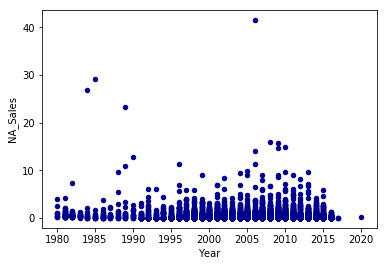

```python
vgs_scatterplot = vgs_df.plot.scatter(x='Year', y='NA_Sales', c='DarkBlue')
```